# Relatório — Estatística Computacional

Mestrado em Bioestatística (UEM)

Disciplina Estatística Computacional Aplicada à Bioestatística

Aluno João Matheus Slujala Krüger Taborda Hneda

Prof. Dr. Josmar Mazucheli

# 1 Introdução

Nesse relatório consta algumas características introdutórias sobre uma nova família de distribuições contínuas denominada de Kumaraswamy Marshall-Olkin Exponential Distribution (KwMOE), a implementação computacional das funções p, d, q e r dessa família, a estimação de alguns parâmetros, estudo de simulação e aplicação em um conjunto de dados.

# 2 Kumaraswamy Marshall-Olkin Exponential Distribution (KwMOE)

A função de densidade dessa família é:

$$\mathrm{f}(\mathrm{x})=\frac{a b(1-p) g(x ; \xi) G(x ; \xi)^{a-1}}{[1-p
\bar{G}(\mathrm{x} ; \xi)]^{a+1}}\left\{1-\left[\frac{G(x ; \xi)}{1-p
\bar{G}(\mathrm{x} ; \xi)}\right]^{a}\right\}^{b-1}$$

E a função distribuição é igual a:

$$\mathrm{F}(\mathrm{x})=1-\left\{1-\left[\frac{G(x ; \xi)}{1-p
\bar{G}(\mathrm{x} ; \xi)}\right]^{a}\right\}^{b}$$

Considerando que X segue uma distribuição exponencial com parâmetro λ > 0,então $\mathrm{g}(\mathrm{x} ; \lambda)=\lambda e^{-\lambda x}, \mathrm{x}>0$ e $\mathrm{G}(\mathrm{x} ; \lambda)=1-e^{-\lambda x}$. Substituindo nas equações acima, temos:

$$f_{K w M O E}(x)=\frac{a b \lambda(1-p) e^{-\lambda
x}\left(1-e^{-\lambda x}\right)^{a-1}}{\left(1-p e^{-\lambda
x}\right)^{a+1}}\left\{1-\left[\frac{1-e^{-\lambda x}}{1-p e^{-\lambda
x}}\right]^{a}\right\}^{b-1}$$
e

$$F(\mathrm{x})=1-\left\{1-\left[\frac{1-e^{-\lambda
x}}{1-p e^{-\lambda x}}\right]^{a}\right\}^{b}$$

A função quantílica é igual a:

$$x_{q}=\frac{1}{\lambda} \log \left\{\frac{1-p\left[1-(1-q)^{1 /
b}\right]^{1 / a}}{1-\left[1-(1-q)^{1 / b}\right]^{1 / a}}\right\}$$

Em suma, a forma das funções dessa família citadas acima depende dos valores de 4 parâmetros, os quais são: λ, a, b, p, sendo que: p = 1 - $\bar{p}$ e λ, a, b, $\bar{p}$, x > 0.

# 3 Observações

Uma das vantagens em se fazer uso dessa família, é que para alguns determinados valores dos parâmetros, tem-se casos particulares de distribuições, como por exemplo:

1. Se p = 0, então a função de densidade pertence a distribuição Kumaraswamy Exponential (KwE)
2. Se a = b = 1, então a função de densidade pertence a **Marshall- Olkin Exponential Distribution (MOE)**
3. Quando a = b = 1 e p = 0, então a função de densidade reduz para a distribuição exponencial.
4. Quando a = 1 e p = 0, temos uma distribuição exponencial com parâmetro bλ.
5. Quando b = 1 e p = 0, nós temos outra exponentiated exponential distribution com parâmetro a e λ, e a função de densidade é $\mathrm{f}(\mathrm{x})=\mathrm{a} \lambda e^{-\lambda x}\left(1-e^{-\lambda x}\right)^{a-1}$

Através da mudança dos parâmetros da distribuição KwMOE, é possível gerar distribuições de várias formas diferentes, como simétricas, assimétricas a esquerda, etc. Porém, por questões didáticas, a implementação das funções foi feita considerando dois parâmetros fixos como padrão (a = b = 1), assim como na parte da estimação via máxima verossimilhança, estudo de simulação e aplicação do modelo em um conjunto de dados. Dessa forma, as páginas posteriores focam em um caso particular da Kumaraswamy Marshall-Olkin Exponential Distribution (KwMOE), que é a **Marshall- Olkin Exponential Distribution (MOE)**.

# 4 Implementação das funções d, p, q, r

## 4.1 d - Probability Density Function (PDF)

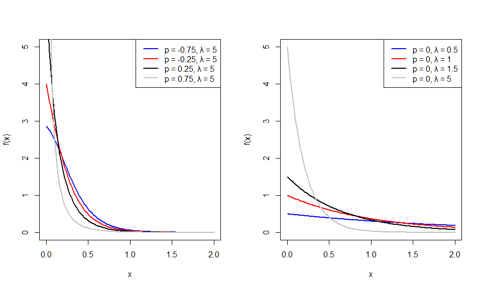

```r
remove(list=ls())

dkwmoe <- function(x,a=1, b=1, pkwmoe, lambda)
{
    dexp <- dexp(x=x,rate=lambda)
    pexp <- pexp(q=x,rate=lambda)

    dKwMOE_p1 <- (a*b*(1-pkwmoe)*dexp*(pexp^(a-1))) / ((1-pkwmoe*(1-pexp))^(a+1))
    dKwMOE_p2 <- (1 - ((pexp)/(1 - pkwmoe*(1-pexp)))^a )^(b-1)
    dKwMOE <- dKwMOE_p1 * dKwMOE_p2
    dKwMOE
}


dkwmoe_curve <- function(a, b, pkwmoe, lambda,
                         col="blue",lwd=2,xlab="x",ylab="f(x)",xlim = c(0, 2), ylim = c(0, 5),add=FALSE) {
    curve(
        dkwmoe(
            x,
            a = a,
            b = b,
            pkwmoe = pkwmoe,
            lambda = lambda
        ),
        col = col, # cor
        #lty=1, # tipo
        lwd = lwd, # tamanho
        xlab = xlab,
        ylab = ylab,
        xlim = xlim,
        ylim = ylim,
        add = add
    )

}
par(mfrow=c(1,2))
params <- list(a=c(1,1,1,1),
               b=c(1,1,1,1),
               pkwmoe=c(-0.75,-0.25,0.25,0.75),
               lambda=c(5,5,5,5),
               col=c("blue","red","black","gray"))

dkwmoe_curve(a = params$a[1],  b = params$b[1], pkwmoe = params$pkwmoe[1], lambda = params$lambda[1], col=params$col[1], add=FALSE)
dkwmoe_curve(a = params$a[2],  b = params$b[2], pkwmoe = params$pkwmoe[2], lambda = params$lambda[2], col=params$col[2], add=TRUE)
dkwmoe_curve(a = params$a[3],  b = params$b[3], pkwmoe = params$pkwmoe[3], lambda = params$lambda[3], col=params$col[3], add=TRUE)
dkwmoe_curve(a = params$a[4],  b = params$b[4], pkwmoe = params$pkwmoe[4], lambda = params$lambda[4], col=params$col[4], add=TRUE)
legend(
    "topright",
    legend = c(
        paste0("p = ",params$pkwmoe[1],", \u03BB = ",params$lambda[1]),
        paste0("p = ",params$pkwmoe[2],", \u03BB = ",params$lambda[2]),
        paste0("p = ",params$pkwmoe[3],", \u03BB = ",params$lambda[3]),
        paste0("p = ",params$pkwmoe[4],", \u03BB = ",params$lambda[4])
    ),
    lty = 1,
    lwd = 2,
    col = params$col
)


params <- list(a=c(1,1,1,1),
               b=c(1,1,1,1),
               pkwmoe=c(0,0,0,0),
               lambda=c(0.5,1,1.5,5),
               col=c("blue","red","black","gray"))

dkwmoe_curve(a = params$a[1],  b = params$b[1], pkwmoe = params$pkwmoe[1], lambda = params$lambda[1], col=params$col[1], add=FALSE)
dkwmoe_curve(a = params$a[2],  b = params$b[2], pkwmoe = params$pkwmoe[2], lambda = params$lambda[2], col=params$col[2], add=TRUE)
dkwmoe_curve(a = params$a[3],  b = params$b[3], pkwmoe = params$pkwmoe[3], lambda = params$lambda[3], col=params$col[3], add=TRUE)
dkwmoe_curve(a = params$a[4],  b = params$b[4], pkwmoe = params$pkwmoe[4], lambda = params$lambda[4], col=params$col[4], add=TRUE)

legend(
    "topright",
    legend = c(
        paste0("p = ",params$pkwmoe[1],", \u03BB = ",params$lambda[1]),
        paste0("p = ",params$pkwmoe[2],", \u03BB = ",params$lambda[2]),
        paste0("p = ",params$pkwmoe[3],", \u03BB = ",params$lambda[3]),
        paste0("p = ",params$pkwmoe[4],", \u03BB = ",params$lambda[4])
    ),
    lty = 1,
    lwd = 2,
    col = params$col
)
```

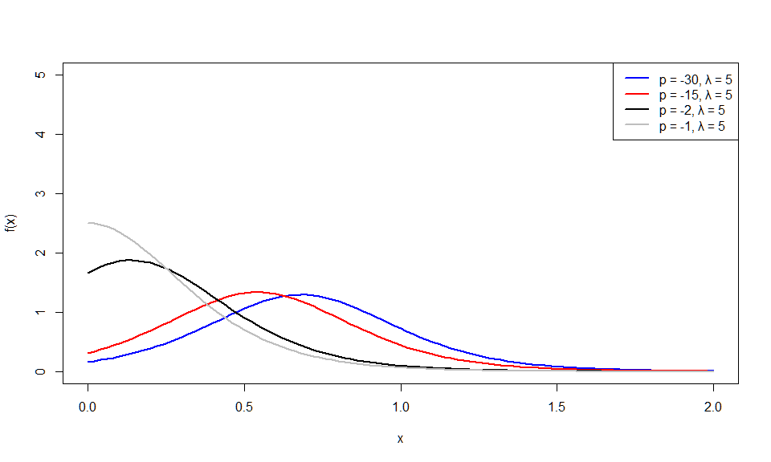

```r
par(mfrow=c(1,1))
params <- list(a=c(1,1,1,1),
               b=c(1,1,1,1),
               pkwmoe=c(-30,-15,-2,-1),
               lambda=c(5,5,5,5),
               col=c("blue","red","black","gray"))

dkwmoe_curve(a = params$a[1],  b = params$b[1], pkwmoe = params$pkwmoe[1], lambda = params$lambda[1], col=params$col[1], add=FALSE)
dkwmoe_curve(a = params$a[2],  b = params$b[2], pkwmoe = params$pkwmoe[2], lambda = params$lambda[2], col=params$col[2], add=TRUE)
dkwmoe_curve(a = params$a[3],  b = params$b[3], pkwmoe = params$pkwmoe[3], lambda = params$lambda[3], col=params$col[3], add=TRUE)
dkwmoe_curve(a = params$a[4],  b = params$b[4], pkwmoe = params$pkwmoe[4], lambda = params$lambda[4], col=params$col[4], add=TRUE)
legend(
    "topright",
    legend = c(
        paste0("p = ",params$pkwmoe[1],", \u03BB = ",params$lambda[1]),
        paste0("p = ",params$pkwmoe[2],", \u03BB = ",params$lambda[2]),
        paste0("p = ",params$pkwmoe[3],", \u03BB = ",params$lambda[3]),
        paste0("p = ",params$pkwmoe[4],", \u03BB = ",params$lambda[4])
    ),
    lty = 1,
    lwd = 2,
    col = params$col
)
```

## 4.2 p - Cumulative Density Function (CDF)

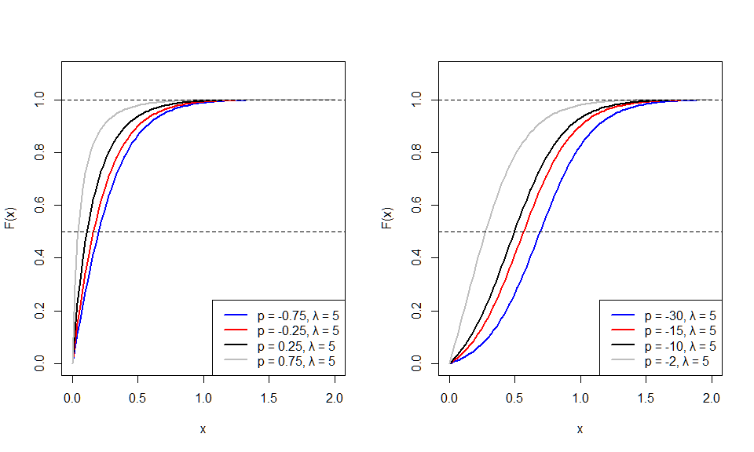

```r
pkwmoe <- function(q, a=1, b=1, pkwmoe, lambda)
{
    pexp <- pexp(q=q,rate=lambda)

    1 - (1-(pexp/(1-pkwmoe*(1-pexp)))^a)^b
}

pkwmoe_curve <- function(x,a=1, b=1, pkwmoe, lambda,
                         col="blue",lwd=2,xlab="x",ylab="F(x)",xlim = c(0, 2), ylim = c(0, 1.1),add=FALSE) {
    curve(
        pkwmoe(
            q = x,
            a = a,
            b = b,
            pkwmoe = pkwmoe,
            lambda = lambda
        ),
        col = col, # cor
        #lty=1, # tipo
        lwd = lwd, # tamanho
        xlab = xlab,
        ylab = ylab,
        xlim = xlim,
        ylim = ylim,
        add = add
    )

}

par(mfrow=c(1,2))
params <- list(a=c(1,1,1,1),
               b=c(1,1,1,1),
               pkwmoe=c(-0.75,-0.25,0.25,0.75),
               lambda=c(5,5,5,5),
               col=c("blue","red","black","gray"))

pkwmoe_curve(a = params$a[1],  b = params$b[1], pkwmoe = params$pkwmoe[1], lambda = params$lambda[1], col=params$col[1], add=FALSE)
pkwmoe_curve(a = params$a[2],  b = params$b[2], pkwmoe = params$pkwmoe[2], lambda = params$lambda[2], col=params$col[2], add=TRUE)
pkwmoe_curve(a = params$a[3],  b = params$b[3], pkwmoe = params$pkwmoe[3], lambda = params$lambda[3], col=params$col[3], add=TRUE)
pkwmoe_curve(a = params$a[4],  b = params$b[4], pkwmoe = params$pkwmoe[4], lambda = params$lambda[4], col=params$col[4], add=TRUE)
legend(
    "bottomright",
    legend = c(
        paste0("p = ",params$pkwmoe[1],", \u03BB = ",params$lambda[1]),
        paste0("p = ",params$pkwmoe[2],", \u03BB = ",params$lambda[2]),
        paste0("p = ",params$pkwmoe[3],", \u03BB = ",params$lambda[3]),
        paste0("p = ",params$pkwmoe[4],", \u03BB = ",params$lambda[4])
    ),
    lty = 1,
    lwd = 2,
    col = params$col
)
abline(h=1,lty=2)
abline(h=0.5,lty=2)

params <- list(a=c(1,1,1,1),
               b=c(1,1,1,1),
               pkwmoe=c(-30,-15,-10,-2),
               lambda=c(5,5,5,5),
               col=c("blue","red","black","gray"))

pkwmoe_curve(a = params$a[1],  b = params$b[1], pkwmoe = params$pkwmoe[1], lambda = params$lambda[1], col=params$col[1], add=FALSE)
pkwmoe_curve(a = params$a[2],  b = params$b[2], pkwmoe = params$pkwmoe[2], lambda = params$lambda[2], col=params$col[2], add=TRUE)
pkwmoe_curve(a = params$a[3],  b = params$b[3], pkwmoe = params$pkwmoe[3], lambda = params$lambda[3], col=params$col[3], add=TRUE)
pkwmoe_curve(a = params$a[4],  b = params$b[4], pkwmoe = params$pkwmoe[4], lambda = params$lambda[4], col=params$col[4], add=TRUE)
legend(
    "bottomright",
    legend = c(
        paste0("p = ",params$pkwmoe[1],", \u03BB = ",params$lambda[1]),
        paste0("p = ",params$pkwmoe[2],", \u03BB = ",params$lambda[2]),
        paste0("p = ",params$pkwmoe[3],", \u03BB = ",params$lambda[3]),
        paste0("p = ",params$pkwmoe[4],", \u03BB = ",params$lambda[4])
    ),
    lty = 1,
    lwd = 2,
    col = params$col
)
abline(h=1,lty=2)
abline(h=0.5,lty=2)
```

## 4.3 q - Quantile Function

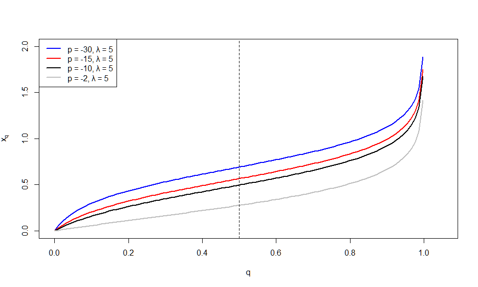

```r
qkwmoe <- function(p, a=1, b=1, pkwmoe, lambda)
{
    num <- 1 - pkwmoe * ( (1 - ((1-p)^(1/b)) )^(1/a) )
    den <- 1 - ( (1 - ((1-p)^(1/b)) )^(1/a) )

    x_q <- (1/lambda) * log(num/den)
    x_q
}

qkwmoe_curve <- function(x,a, b, pkwmoe, lambda,
                         col="blue",lwd=2,xlab="q",ylab = "x_q",xlim = c(0, 1.05), ylim = c(0, 2),add=FALSE) {
    curve(
        qkwmoe(
            p=x,
            a = a,
            b = b,
            pkwmoe = pkwmoe,
            lambda = lambda
        ),
        col = col, # cor
        #lty=1, # tipo
        lwd = lwd, # tamanho
        xlab = xlab,
        ylab= latex2exp::TeX(sprintf(r'($%s$)', ylab)),
        xlim = xlim,
        ylim = ylim,
        add = add
    )

}


params <- list(a=c(1,1,1,1),
               b=c(1,1,1,1),
               pkwmoe=c(-30,-15,-10,-2),
               lambda=c(5,5,5,5),
               col=c("blue","red","black","gray"))

qkwmoe_curve(a = params$a[1],  b = params$b[1], pkwmoe = params$pkwmoe[1], lambda = params$lambda[1], col=params$col[1], add=FALSE)
qkwmoe_curve(a = params$a[2],  b = params$b[2], pkwmoe = params$pkwmoe[2], lambda = params$lambda[2], col=params$col[2], add=TRUE)
qkwmoe_curve(a = params$a[3],  b = params$b[3], pkwmoe = params$pkwmoe[3], lambda = params$lambda[3], col=params$col[3], add=TRUE)
qkwmoe_curve(a = params$a[4],  b = params$b[4], pkwmoe = params$pkwmoe[4], lambda = params$lambda[4], col=params$col[4], add=TRUE)
legend(
    "topleft",
    legend = c(
        paste0("p = ",params$pkwmoe[1],", \u03BB = ",params$lambda[1]),
        paste0("p = ",params$pkwmoe[2],", \u03BB = ",params$lambda[2]),
        paste0("p = ",params$pkwmoe[3],", \u03BB = ",params$lambda[3]),
        paste0("p = ",params$pkwmoe[4],", \u03BB = ",params$lambda[4])
    ),
    lty = 1,
    lwd = 2,
    col = params$col
)
abline(v=0.5,lty=2)
```

## 4.4 r - Random Generation

```r
rkwmoe <- function(n, a=1, b=1, pkwmoe, lambda)
{
    U <- runif(n)
    num <- 1 - pkwmoe * ( (1 - ((1-U)^(1/b)) )^(1/a) )
    den <- 1 - ( (1 - ((1-U)^(1/b)) )^(1/a) )

    x_q <- (1/lambda) * log(num/den)
    x_q
}

params <- list(a=c(1,1,1,1),
               b=c(1,1,1,1),
               pkwmoe=c(-30,-15,-10,-2),
               lambda=c(5,5,5,5))

rkwmoe(n=10,a = params$a[1],  b = params$b[1], pkwmoe = params$pkwmoe[1], lambda = params$lambda[1])
```

```
##  [1] 0.4944890 0.2322741 1.0313969 0.4870240 1.0671891 0.3900775 0.6530809
##  [8] 0.7701007 0.4971720 0.5594458
```

```r
rkwmoe(n=10,a = params$a[2],  b = params$b[2], pkwmoe = params$pkwmoe[2], lambda = params$lambda[2])
```

```
##  [1] 0.3289674 0.7795126 0.4910946 0.3152191 0.2221961 1.0051542 0.2808916
##  [8] 0.2271674 0.5822965 0.6429505
```

```r
rkwmoe(n=10,a = params$a[3],  b = params$b[3], pkwmoe = params$pkwmoe[3], lambda = params$lambda[3])
```

```
##  [1] 0.48846934 0.08070178 0.55966568 0.50766153 0.23992179 0.57392165
##  [7] 0.17466421 0.39253066 1.44997334 0.83040913
```

```r
rkwmoe(n=10,a = params$a[4],  b = params$b[4], pkwmoe = params$pkwmoe[4], lambda = params$lambda[4])
```

```
##  [1] 0.06160941 0.55347440 0.06157744 0.22189200 0.86304975 0.20842371
##  [7] 0.81381851 0.13670494 0.43805902 0.09272338
```

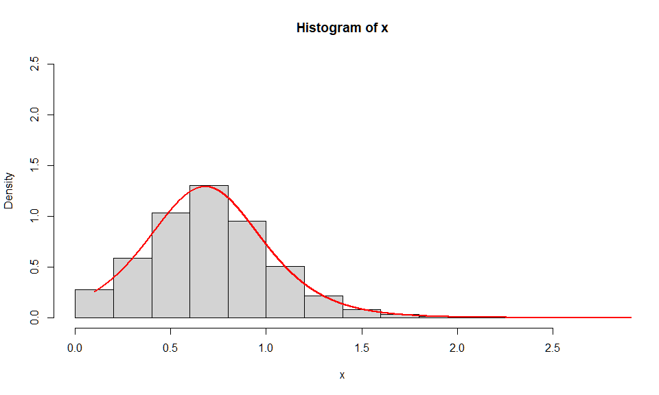

```r
set.seed(123)
x <- rkwmoe(
        n = 10000,
        a = params$a[1],
        b = params$b[1],
        pkwmoe = params$pkwmoe[1],
        lambda = params$lambda[1]
    )
hist(x, prob = T, ylim = c(0,2.5))
y <- seq(0.1, 100, 0.0001)
lines(
    y,
    dkwmoe(
        y,
        a = params$a[1],
        b = params$b[1],
        pkwmoe = params$pkwmoe[1],
        lambda = params$lambda[1]
    ),
    lwd = 2,
    col = "red"
)
```

# 5 Estimação via máxima verossimilhança e Estudo de simulação

## 5.1 Estimação via máxima verossimilhança

```r
dados     <-  x
mle   <-  fitdistrplus::fitdist(dados, distr = 'kwmoe', method = "mle",
                start = list(pkwmoe = params$pkwmoe[1],lambda =params$lambda[1]),
                fix.arg=list(a = params$a[1], b = params$b[1])#,
                #lower=c(0.01,0.01),
                )$estimate
mle
```

```
##     pkwmoe     lambda
## -31.122942   5.069437
```

## 5.2 Estudo de simulação

```r
library(fitdistrplus)
B     <-  2000
n     <-  seq(20, 200, 30)
L     <-  length(n)
param <-  c(1, 1, 0.9, 6)
mle   <-  list()
mle   <-  matrix(ncol = 2, nrow = B)
vies  <-  rmse <- matrix(ncol = 2, nrow = L)
```

```r
for(j in 1:L)
{
  set.seed(123)
  for(i in 1:B)
    #print(i)
  {
    dados     <-  rkwmoe(n[j], a = param[1], b = param[2], pkwmoe = param[3], lambda = param[4])
    mle[i,]   <-  fitdistrplus::fitdist(dados, distr = 'kwmoe', method = "mle",
                    start = list(pkwmoe = param[3],lambda = param[4]),
                    fix.arg=list(a = param[1], b = param[2])#,
                    #lower=c(0.01,0.01),
                    )$estimate
  }
  aux         <-   mle - matrix(param[c(3,4)], ncol = 2, nrow = B, byrow = T)
  vies[j,]    <-   apply(aux, 2, mean, na.rm = T)
  rmse[j,]    <-   apply(aux ^  2, 2, mean, na.rm = T)
  cat(i, n[j], "\n")
}
```

```
## 2000 20
## 2000 50
## 2000 80
## 2000 110
## 2000 140
## 2000 170
## 2000 200
```

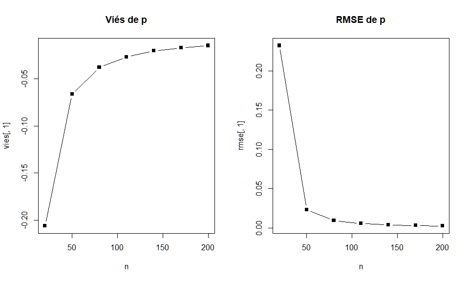

```r
par(mfrow = c(1, 2))
plot(n, vies[,1], type = "b", pch = 15, main = "Viés de p")
plot(n, rmse[,1], type = "b", pch = 15, main = "RMSE de p")
```

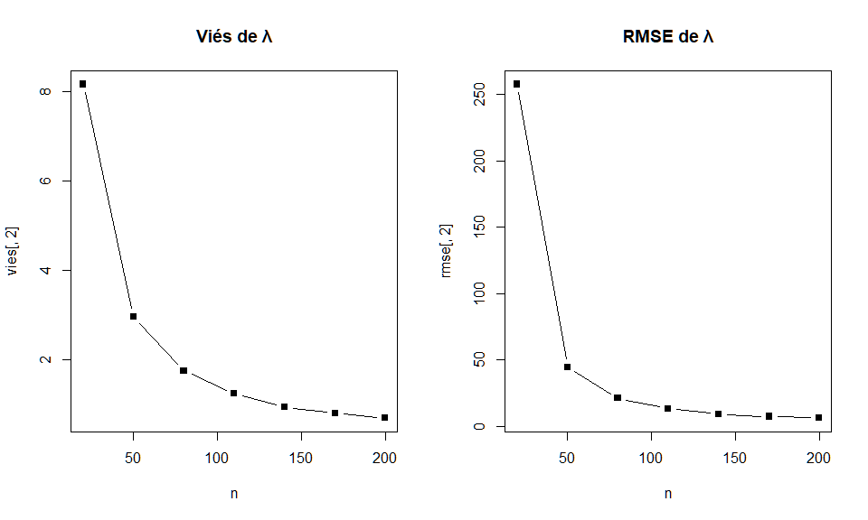

```r
plot(n, vies[,2], type = "b", pch = 15, main = "Viés de \u03BB")
plot(n, rmse[,2], type = "b", pch = 15, main = "RMSE de \u03BB")
```

# 6 Aplicação

Os dados são relativos às corridas marcadas por um jogador de críquete em 27 entradas a nível nacional.

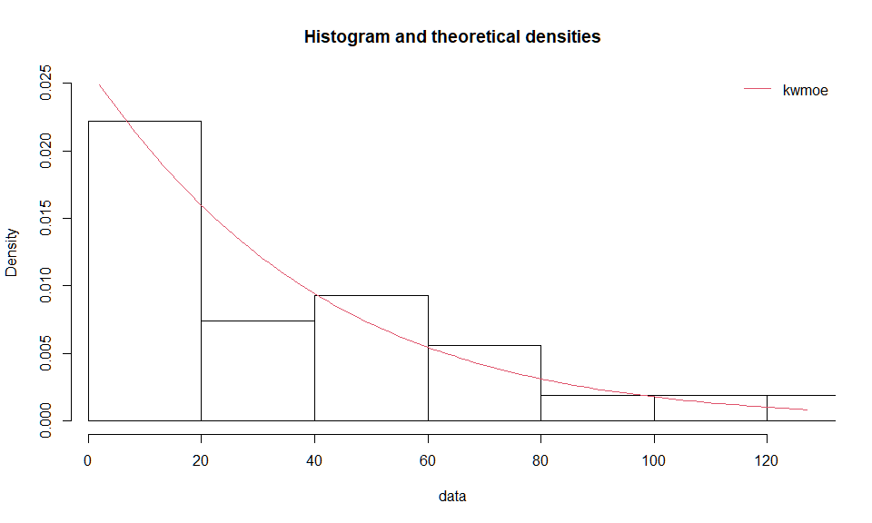

```r
x <- c(28,20,6,4,23,127,25,45,41,67,68,3,17,2,
105,98,55,68,15,3,42,45,7,20,34,9,6)

library(fitdistrplus)
fit.kwmoe <- fitdistrplus::fitdist(x, distr = 'kwmoe', method = "mle",
                    start = list(pkwmoe = -30,lambda = 2),
                    fix.arg=list(a = 1, b = 1)#,
                    #lower=c(0.01,0.01),
                    )
denscomp(fit.kwmoe)
```

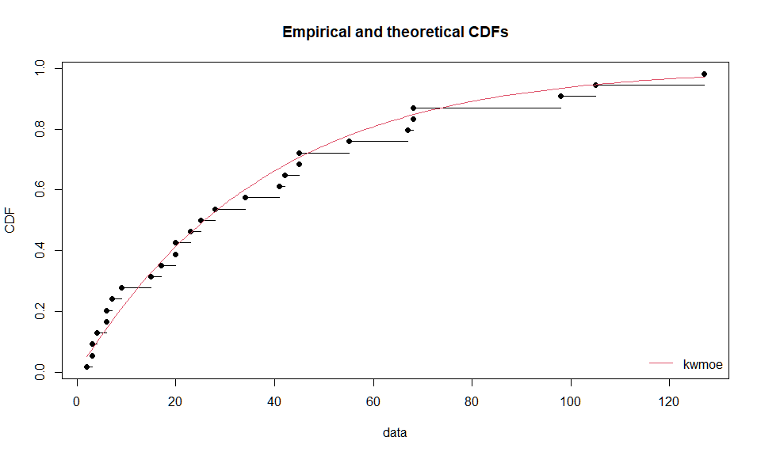

```r
cdfcomp(fit.kwmoe)
```

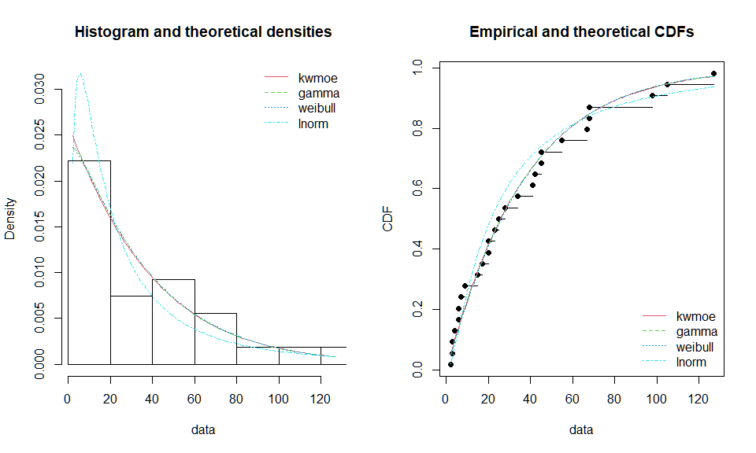

```r
fit.gamma  <- fitdist(data = x, distr = 'gamma', start = list(shape = 1, scale = 1))
fit.weibul  <- fitdist(data = x, distr = 'weibull', start = list(shape = 1, scale = 1))
fit.logn    <- fitdist(data = x, distr = 'lnorm', start = list(meanlog = 1, sdlog = 1))

par(mfrow=c(1,2))
denscomp(list(fit.kwmoe,fit.gamma,fit.weibul, fit.logn))
cdfcomp(list(fit.kwmoe,fit.gamma,fit.weibul, fit.logn))
```

```r
gofstat(list(fit.kwmoe,fit.gamma,fit.weibul, fit.logn), fitnames = c("kwmoe","gamma", "weibull", "logn"))
```

```
## Goodness-of-fit statistics
##                                   kwmoe      gamma    weibull       logn
## Kolmogorov-Smirnov statistic 0.09095579 0.09797561 0.09822703 0.12039444
## Cramer-von Mises statistic   0.03072019 0.03451216 0.03402396 0.08321807
## Anderson-Darling statistic   0.23964974 0.26469493 0.26295124 0.51777972
##
## Goodness-of-fit criteria
##                                   kwmoe    gamma  weibull     logn
## Akaike's Information Criterion 252.0940 252.0484 252.0412 254.0447
## Bayesian Information Criterion 254.6857 254.6401 254.6329 256.6364
```

# 7 Conclusão

Na literatura estatística, é importante que novas distribuições de probabilidade sejam elaboradas para explicar os fenômenos da natureza. O modelo apresentado nesse relatório demonstrou-se interessante para ser utilizado pois possui boas medidas de qualidade de ajuste e, portanto, tem a capacidade de auxiliar na explicação do fenômeno estudado.

# 8 Referências

- Roshini George & S. Thobias (2019) Kumaraswamy Marshall-Olkin Exponential distribution, Communications in Statistics - Theory and Methods, 48:8, 1920-1937, DOI: 10.1080/03610926.2018.1440594
- T. A. Raja and A. H. Mir - On Extension of Some Exponentiated Distributions with Application
- Adepoju, K. A. and Chukwu, O. I. (2015) “Maximum Likelihood Estimation of the Kumaraswamy Exponential Distribution with Applications,” Journal of Modern Applied Statistical Methods: Vol. 14 : Iss. 1 , Article 18. DOI: 10.22237/jmasm/1430453820 Available at: http://digitalcommons.wayne.edu/jmasm/vol14/iss1/18

[figure not shown]